# Tutorial 3: Flow Regime Classification and Pump Fault Detection Using Margin-Based Models

CHEE4003: Special Topics A - Artificial Intelligence in Chemical Engineering

Published

October 8, 2026

# Linear Classifiers and Margin-Based Models

In Tutorial 2, we classified data using a distance-based model (k-NN) and tree-based models (Decision Tree, Random Forest). In this tutorial, we look at two models that instead learn a **decision boundary** directly in the feature space: **logistic regression** and the **support vector machine (SVM)**.

Both models draw a boundary between classes, but they choose *where* to draw it differently. Logistic regression places the boundary to maximise the **likelihood** of the observed labels; it models the *probability* of each class. The SVM is a **margin-based** model: it places the boundary to maximise the **margin**, the gap between the boundary and the nearest data points of each class. Those nearest points are called the **support vectors**, and they alone define the boundary. Maximising this margin tends to improve generalisation and reduce overfitting. With the **kernel trick**, an SVM can also bend the boundary to separate classes that a straight line cannot.

We will train **logistic regression** to classify two-phase **flow regimes**, and an **SVM** to detect a **pump failure** in an evaporator.

Before anything else, we need to have the correct libraries imported. Copy the following code into your script to import the necessary libraries:

```
import_libraries.py
```

```python
import numpy as np
import pandas as pd
import matplotlib.pyplot as plt
import seaborn as sns
from sklearn.preprocessing import LabelEncoder, StandardScaler
from sklearn.model_selection import train_test_split
from sklearn.linear_model import LogisticRegression
from sklearn.svm import SVC
from sklearn.metrics import ConfusionMatrixDisplay, precision_score, recall_score,  f1_score, confusion_matrix
```

## Part A: Logistic Regression on Flow Regime

When gas and liquid flow simultaneously through a horizontal pipe, as commonly encountered in reboilers, condensers, pipelines, and multiphase reactors, the two phases can be arranged into distinct flow patterns, known as **flow regimes**. These regimes depend primarily on the gas and liquid velocities, fluid properties, pipe geometry, and operating conditions. As the phase velocities change, the flow may transition through several characteristic regimes, including bubbly, plug, stratified, slug, annular, and mist flow, each exhibiting unique hydrodynamic behavior and transport characteristics, as shown in Figure Figure 1.

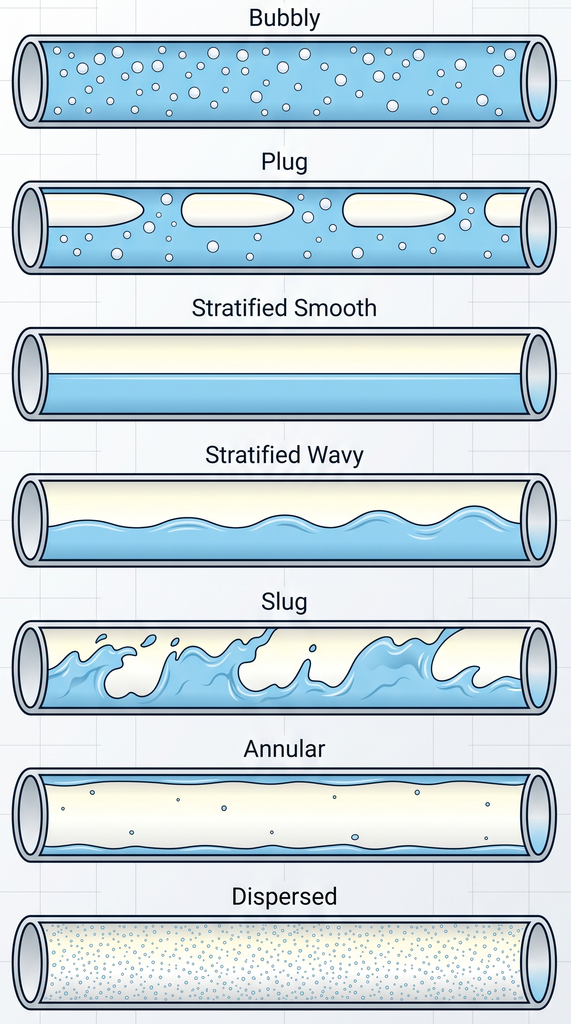

Figure 1: Horizontal pipe flow regimes: bubbly, plug, stratified, slug, annular, and dispersed.

Although many flow regimes are possible, including bubbly, plug, stratified, slug, annular, and dispersed flow, only **three regimes** (i.e., stratified, slug, and Annular) are represented in this dataset.

| Flow Regime | Description |
| --- | --- |
| **Stratified** | Gas and liquid remain largely separated, with liquid flowing along the bottom of the pipe and gas occupying the upper section. This regime typically occurs at relatively low phase velocities. |
| **Slug** | Large gas bubbles intermittently occupy most of the pipe cross-section, separated by liquid slugs. This highly unsteady regime can cause significant fluctuations in pressure and flow. |
| **Annular** | A high-velocity gas core flows through the centre of the pipe while a thin liquid film coats the pipe wall. This regime is commonly observed at high gas velocities. |

Identifying the flow regime is important because it strongly influences pressure drop, heat and mass transfer rates, phase distribution, and the likelihood of operational issues such as vibration, flow instability, or flooding. In this exercise, we will use **logistic regression** to predict the flow regime from measurements of gas and liquid flow conditions in a horizontal pipe.

Download the dataset below to get started.

```
flow_regime.csv
```

```
Gas_velocity_(m/s),Liq_velocity_(m/s),Flow
0.7,0.5,Slug
0.8,0.5,Slug
1,0.5,Slug
1.44,0.5,Slug
... (130 more lines)
```

Below is a description of each of the variables in the dataset:

| Feature | Description |
| --- | --- |
| Gas_velocity_(m/s) | Superficial gas velocity [m/s] |
| Liq_velocity_(m/s) | Superficial liquid velocity [m/s] |
| Flow | Flow regime: Annular, Slug, or Stratified (**the label**) |

**NoteWhat is logistic regression?**

Logistic regression is a **classification** algorithm that predicts the probability that a sample belongs to a particular class. It first forms a weighted combination of the input features,

$$z = w_1x_1 + w_2x_2 + \dots + b$$

and then converts this value into a probability using the **logistic (sigmoid) function**:

$$\sigma(z)=\frac{1}{1+e^{-z}}$$

which squashes the result into a probability between 0 and 1. The class is decided by whether this probability crosses 0.5. The set of points where it *equals* 0.5 is a straight line (a **linear decision boundary**) in feature space.

For problems with more than two classes, such as the flow regimes in this dataset, *scikit-learn* uses a **multinomial logistic regression** model that estimates a probability for each class and predicts the most likely one (through the use of the **softmax** function).

Because logistic regression uses a linear combination of the features, it produces **linear decision boundaries** in the feature space.

For more information about `LogisticRegression`, refer to the official scikit-learn [documentation](https://scikit-learn.org/stable/modules/generated/sklearn.linear_model.LogisticRegression.html#sklearn.linear_model.LogisticRegression)

### Task 1 : Load the dataset

Write a function `load_flow_regime_data` that loads the dataset and returns the features `X` (a pandas DataFrame containing the two velocity variables) and the labels `y` (a pandas Series containing the integer-encoded flow regimes). Because the labels are text (`"Annular"`, `"Slug"`, `"Stratified"`), use scikit-learn’s `LabelEncoder` to convert them to integers (0, 1, 2). The function should also return the class names so we can label plots later, and print the shapes to confirm the data loaded correctly.

**TipEncoding text labels with `LabelEncoder`**

`LabelEncoder` turns a column of text categories into integers. First, define an encoder object via `LabelEncoder()`, and then use it to apply it to the relevant data: `encoder.fit_transform(column)`. You can then use `encoder.classes_` afterwards to recover the original names in integer order (0, 1, 2, …). For more information about `LabelEncoder`, refer to the official scikit-learn [documentation](https://scikit-learn.org/stable/modules/generated/sklearn.preprocessing.LabelEncoder.html).

The function description is provided below:

```
load_flow_regime_data.py
```

```python
def load_flow_regime_data(file_path):
    """
    Load the flow regime dataset and return the features, encoded labels, and class names.

    Parameters
    ----------
    file_path : str
        Path to the CSV file containing the flow regime dataset.

    Returns
    -------
    X : pd.DataFrame
        DataFrame containing the input features:
        gas velocity and liquid velocity.

    y : pd.Series
        Series containing the flow regime labels encoded as integers.

    class_names : np.ndarray
        Array containing the original flow regime class names corresponding
        to the encoded labels.
    """

    return X, y, class_names
```

When you run this function, it should yield the following output:

X, y, class_names = load_flow_regime_data('data/flow_regime.csv')

Features shape: (133, 2)

Labels shape: (133,)

Classes: ['Annular', 'Slug', 'Stratified']

**Callout-answer**Answer**

```
load_flow_regime_data.py
```

```python
def load_flow_regime_data(file_path):
    """
    Load the flow regime dataset and return the features, encoded labels, and class names.

    Parameters
    ----------
    file_path : str
        Path to the CSV file containing the flow regime dataset.

    Returns
    -------
    X : pd.DataFrame
        DataFrame containing the input features:
        gas velocity and liquid velocity.

    y : pd.Series
        Series containing the flow regime labels encoded as integers.

    class_names : np.ndarray
        Array containing the original flow regime class names corresponding
        to the encoded labels.
    """
    # Load the dataset
    data = pd.read_csv(file_path)

    # Features: the two velocity columns.
    X = data.iloc[:, :2]

    # Labels: the flow regime, encoded to integers.
    encoder = LabelEncoder()
    y = pd.Series(encoder.fit_transform(data["Flow"]))
    class_names = encoder.classes_

    print(f"Features shape: {X.shape}")
    print(f"Labels shape: {y.shape}")
    print(f"Classes: {list(class_names)}")
    return X, y, class_names

X, y, class_names = load_flow_regime_data('data/flow_regime.csv')
```

Output

```
Features shape: (133, 2)
Labels shape: (133,)
Classes: ['Annular', 'Slug', 'Stratified']
```

### Task 2 : Explore the dataset

Once the dataset is loaded, we can explore its structure and gain insights into the data. Write a function `explore_data` that starts by displaying the first few rows of the features and labels using `.head()`. Next, use `.describe()` to obtain a statistical summary of the velocity variables, including their mean, standard deviation, and range. Finally, use `.value_counts()` to determine the number of samples belonging to each flow regime.

```
explore_data.py
```

```python
def explore_data(X, y):
    """
    Explore the dataset by printing the first 5 rows, summary statistics,
    and label distribution.

    Parameters
    ----------
    X : pd.DataFrame
        A Pandas DataFrame containing the features (input variables).

    y : pd.Series
        A Pandas Series containing the labels (output variable).

    Returns
    -------
    None
        Prints the first 5 rows of the dataset, summary statistics for the
        features, and the distribution of the labels.
    """
```

Here is what your function should output:

explore_data(X, y)

First 5 rows of features:

Gas_velocity_(m/s) Liq_velocity_(m/s)

0 0.70 0.5

1 0.80 0.5

2 1.00 0.5

3 1.44 0.5

4 2.00 0.5

First 5 rows of labels:

0 1

1 1

2 1

3 1

4 1

dtype: int64

Summary statistics of features:

Gas_velocity_(m/s) Liq_velocity_(m/s)

count 133.000000 133.000000

mean 14.413534 0.888571

std 17.531068 1.015201

min 0.200000 0.030000

25% 1.000000 0.100000

50% 3.000000 0.500000

75% 30.000000 1.400000

max 50.000000 4.000000

Label distribution:

0 49

2 44

1 40

Name: count, dtype: int64

This will help us understand the range of gas and liquid velocities in the dataset, and determine whether the flow regime classes are balanced before training a machine learning model.

### Task 3 : Visualise the data in log-space

Both velocities span more than an order of magnitude, so we first apply a **log₁₀ transform**. This spreads the data out evenly and, as you will see, makes the three regimes separate along roughly straight lines, exactly the kind of boundary logistic regression can draw. Create the transformed feature array:

```python
X_log = np.log10(X.values)
```

Now write a function `plot_flow_regime` that produces a scatter plot of the (log-transformed) gas velocity against the liquid velocity, colouring each point by its flow regime.

```
plot_flow_regime.py
```

```python
def plot_flow_regime(X, y, class_names):
    """
    Scatter plot of the two (log-transformed) velocity features, coloured by flow regime.

    Parameters
    ----------
    X : np.ndarray
        A 2D array of features (log-transformed velocities).

    y : np.ndarray
        A 1D array of encoded labels.

    class_names : np.ndarray
        The text label for each encoded class.

    Returns
    -------
    None
        Displays a flow regime map showing the distribution of samples
        in the feature space coloured according to their flow regime.
    """
```

Your plot should look like the figure below.

plot_flow_regime(X_log, y, class_names)

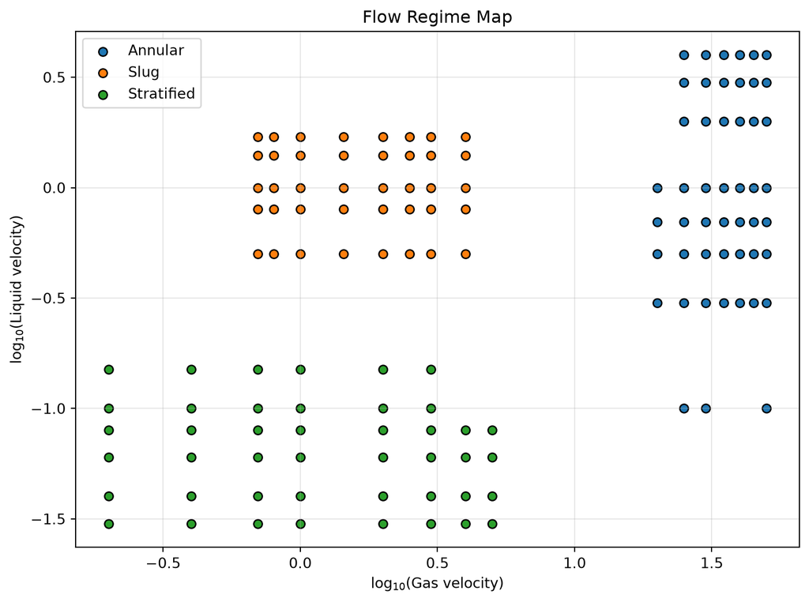

**NoteWhy the log-transform?**

Superficial velocities in multiphase flow commonly range over several orders of magnitude, so on linear axes the low-velocity points bunch together in one corner. Taking the logarithm stretches them apart and, physically, flow-regime maps are conventionally drawn on log–log axes for exactly this reason (recall the moody diagram!).

**Callout-answer**Answer**

```
plot_flow_regime.py
```

```python
def plot_flow_regime(X, y, class_names):
    """
    Scatter plot of the two (log-transformed) velocity features, coloured by flow regime.

    Parameters
    ----------
    X : np.ndarray
        A 2D array of features (log-transformed velocities).

    y : np.ndarray
        A 1D array of encoded labels.

    class_names : np.ndarray
        The text label for each encoded class.

    Returns
    -------
    None
        Displays a flow regime map showing the distribution of samples
        in the feature space coloured according to their flow regime.
    """

    plt.figure(figsize=(8, 6))
    for i, name in enumerate(class_names):
        plt.scatter(X[y == i, 0], X[y == i, 1], color=f"C{i}", label=name, edgecolor="k")
    plt.xlabel("log$_{10}$(Gas velocity)")
    plt.ylabel("log$_{10}$(Liquid velocity)")
    plt.title("Flow Regime Map")
    plt.legend()
    plt.grid(True, alpha=0.3)
    plt.tight_layout()
    plt.show()

plot_flow_regime(X_log, y, class_names)
```

Output

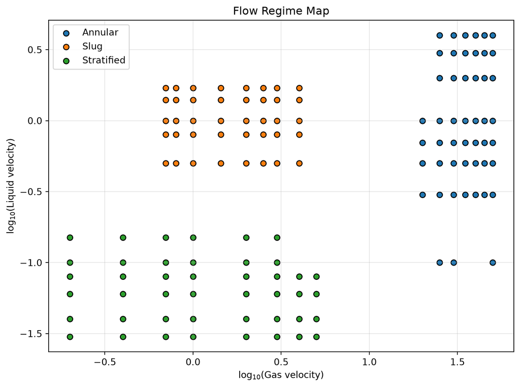

### Task 4 : Split into training, validation and testing sets

As in Tutorial 2, we split the data into **training**, **validation**, and **testing** sets so that we can estimate model performance on unseen samples. The training set is used to fit the model, the validation set is used to select hyperparameters, and the testing set is reserved for the final evaluation of the chosen model.

Write a function `preprocess_data` that splits the features and labels into training, validation, and testing sets using `train_test_split`. Use a 70% training split, then split the remaining 30% equally into validation and testing sets (15% each). Use a `random_state` of `42` for reproducibility and stratify the splits to preserve the class distribution across all subsets.

```
preprocess_data.py
```

```python
def preprocess_data(X, y, temp_size=0.3, test_size=0.50, random_state=42):
    """
    Preprocess the dataset by splitting into training, validation,
    and testing sets.

    Parameters
    ----------
    X : pd.DataFrame
        A Pandas DataFrame containing the features (input variables).
    y : pd.Series
        A Pandas Series containing the labels (output variable).
    train_size : float, optional
        The proportion of the dataset to include in the training set
        (default is 0.70).
    temp_size : float, optional
        The proportion of the dataset to reserve for validation and
        testing (default is 0.30).
    test_size : float, optional
        The proportion of the temporary data to include in the test set
        (default is 0.50, resulting in a 15% test set and 15% validation set).
    random_state : int, optional
        The random seed for reproducibility (default is 42).

    Returns
    -------
    X_train : pd.DataFrame
        Training features.
    X_val : pd.DataFrame
        Validation features.
    X_test : pd.DataFrame
        Testing features.
    y_train : pd.Series
        Training labels.
    y_val : pd.Series
        Validation labels.
    y_test : pd.Series
        Testing labels.
    """

    return X_train, X_val, X_test, y_train, y_val, y_test
```

X_train, X_val, X_test, y_train, y_val, y_test = preprocess_data(X_log, y)

X_train.shape, X_val.shape, X_test.shape, y_train.shape, y_val.shape, y_test.shape

((93, 2), (20, 2), (20, 2), (93,), (20,), (20,))

**Note**

Notice we split the **log-transformed** features (`X_log`), not the raw velocities. Any transformation of the features happens *before* the split; the split only decides which rows are used for training and which are held back for validation and testing.

**Callout-answer**Answer**

```
preprocess_data.py
```

```python
def preprocess_data(X, y, temp_size=0.3, test_size=0.50, random_state=42):
    """
    Preprocess the dataset by splitting into training, validation,
    and testing sets.

    Parameters
    ----------
    X : pd.DataFrame
        A Pandas DataFrame containing the features (input variables).
    y : pd.Series
        A Pandas Series containing the labels (output variable).
    train_size : float, optional
        The proportion of the dataset to include in the training set
        (default is 0.70).
    temp_size : float, optional
        The proportion of the dataset to reserve for validation and
        testing (default is 0.30).
    test_size : float, optional
        The proportion of the temporary data to include in the test set
        (default is 0.50, resulting in a 15% test set and 15% validation set).
    random_state : int, optional
        The random seed for reproducibility (default is 42).

    Returns
    -------
    X_train : pd.DataFrame
        Training features.
    X_val : pd.DataFrame
        Validation features.
    X_test : pd.DataFrame
        Testing features.
    y_train : pd.Series
        Training labels.
    y_val : pd.Series
        Validation labels.
    y_test : pd.Series
        Testing labels.
    """

    # Split the dataset into a training set (70%) and a temporary set (30%)
    X_train, X_temp, y_train, y_temp = train_test_split(X, y, test_size=temp_size,stratify=y, random_state=random_state)

    # Split the temporary set equally into validation (15%) and testing (15%)
    X_val, X_test, y_val, y_test = train_test_split(X_temp, y_temp, test_size=test_size,stratify=y_temp, random_state=random_state)

    return X_train, X_val, X_test, y_train, y_val, y_test

X_train, X_val, X_test, y_train, y_val, y_test = preprocess_data(X_log, y)
X_train.shape, X_val.shape, X_test.shape, y_train.shape, y_val.shape, y_test.shape
```

Output

```
((93, 2), (20, 2), (20, 2), (93,), (20,), (20,))
```

**TipDo we need to scale the features here?**

For an SVM we will (Part B), but here the two features are *already* on a similar scale after the log-transform, so scaling makes little difference to logistic regression. We keep the features in log-velocity units so the decision boundary we plot shortly stays physically interpretable.

### Task 5 : Train the logistic regression model

```
train_logistic_regression.py
```

```python
def train_logistic_regression(X_train, y_train, X_val, y_val, C=1):
    """
    Train a Logistic Regression classifier using the training features
    and labels.

    Parameters
    ----------
    X_train : pd.DataFrame
        Training features.
    y_train : pd.Series
        Training labels.
    X_val : pd.DataFrame
        Validation features.
    y_val : pd.Series
        Validation labels.
    C : float, optional
        Inverse regularisation strength (default is 1.0).

    Returns
    -------
    lr_model : LogisticRegression
        The trained Logistic Regression classifier.
    accuracy_train : float
        Accuracy of the model on the training set.
    accuracy_val : float
        Accuracy of the model on the validation set.
    """
    return model, accuracy_train, accuracy_val
```

C=0.5

lr_model, accuracy_train, accuracy_val = train_logistic_regression(X_train, y_train, X_val, y_val, C)

print(f"Logistic regression training accuracy: {accuracy_train:.4f}")

Logistic regression training accuracy: 1.0000

print(f"Logistic regression validation accuracy: {accuracy_val:.4f}")

Logistic regression validation accuracy: 1.0000

**Callout-answer**Answer**

```
train_logistic_regression.py
```

```python
def train_logistic_regression(X_train, y_train, X_val, y_val, C=1):
    """
    Train a Logistic Regression classifier using the training features
    and labels.

    Parameters
    ----------
    X_train : pd.DataFrame
        Training features.
    y_train : pd.Series
        Training labels.
    X_val : pd.DataFrame
        Validation features.
    y_val : pd.Series
        Validation labels.
    C : float, optional
        Inverse regularisation strength (default is 1.0).

    Returns
    -------
    lr_model : LogisticRegression
        The trained Logistic Regression classifier.
    accuracy_train : float
        Accuracy of the model on the training set.
    accuracy_val : float
        Accuracy of the model on the validation set.
    """

    lr_model = LogisticRegression(C=C)

    # Train the Logistic Regression classifier
    lr_model.fit(X_train, y_train)

    # Evaluate the accuracy on the training set
    accuracy_train = lr_model.score(X_train, y_train)

    # Evaluate the accuracy on the validation set
    accuracy_val = lr_model.score(X_val, y_val)

    return lr_model, accuracy_train, accuracy_val

C=0.5
lr_model, accuracy_train, accuracy_val = train_logistic_regression(X_train, y_train, X_val, y_val, C)
print(f"Logistic regression training accuracy: {accuracy_train:.4f}")
print(f"Logistic regression validation accuracy: {accuracy_val:.4f}")
```

Output

```
Logistic regression training accuracy: 1.0000
Logistic regression validation accuracy: 1.0000
```

### Task 6 : Evaluate with a confusion matrix

A **confusion matrix** shows *which* classes the model confuses, and is much more useful than a raw accuracy score. Each row is a true class and each column is a predicted class, so correct predictions sit on the diagonal and mistakes appear off it. Write a function `plot_confusion_matrix` that displays the confusion matrix for a fitted model using scikit-learn’s `ConfusionMatrixDisplay.from_estimator`.

**TipDrawing the matrix with `ConfusionMatrixDisplay`**

`ConfusionMatrixDisplay.from_estimator(model, X_val, y_val)` runs the model on the test set and plots the matrix in a single call. See the attached documentation for more: [scikit-learn](https://scikit-learn.org/stable/modules/generated/sklearn.metrics.ConfusionMatrixDisplay.html).

```
plot_confusion_matrix.py
```

```python
def plot_confusion_matrix(model, X_val, y_val, class_names):
    """
    Display the confusion matrix for a fitted classifier on the test set.

    Parameters
    ----------
    model : fitted scikit-learn classifier
        The trained model to evaluate.
    X_val, y_val : np.ndarray
        The validation features and labels.
    class_names : np.ndarray
        The text label for each class (used to label the axes).

    Returns
    -------
    None
        Displays the confusion matrix plot.
    """
```

plot_confusion_matrix(lr_model, X_val, y_val, class_names)

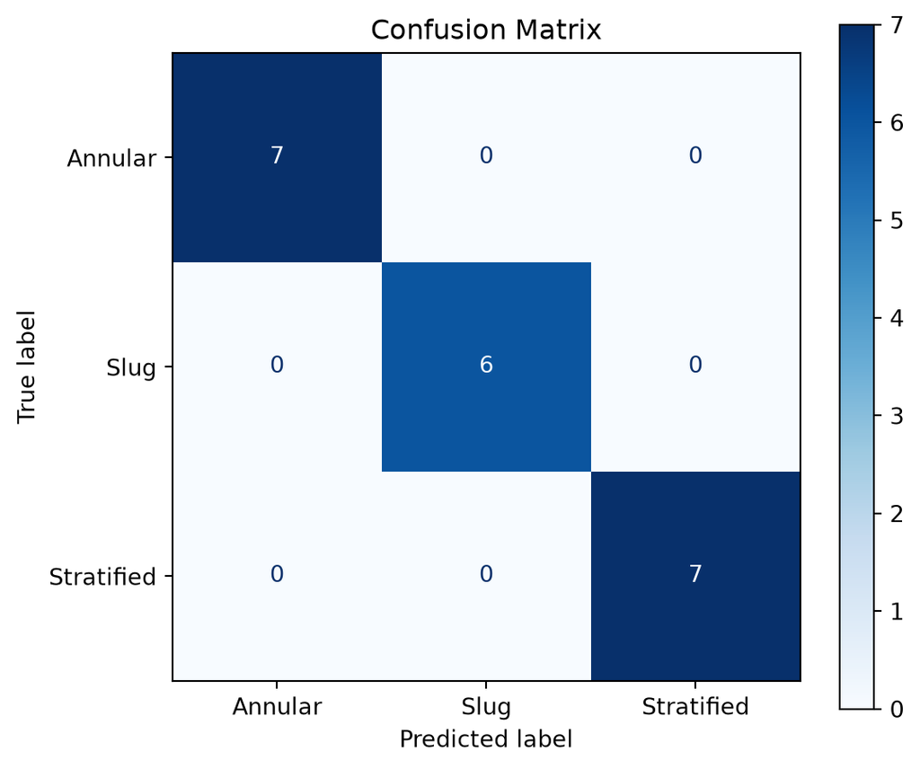

**NoteReading a confusion matrix**

Here the matrix is entirely on the diagonal: the model classifies every test point correctly. That is possible because the three regimes are so cleanly separated in log-space. On a messier, real-world dataset you would expect to see some off-diagonal entries, and those are usually where the interesting engineering questions live.

**Callout-answer**Answer**

```
plot_confusion_matrix.py
```

```python
def plot_confusion_matrix(model, X_val, y_val, class_names):
    """
    Display the confusion matrix for a fitted classifier on the test set.

    Parameters
    ----------
    model : fitted scikit-learn classifier
        The trained model to evaluate.
    X_val, y_val : np.ndarray
        The validation features and labels.
    class_names : np.ndarray
        The text label for each class (used to label the axes).

    Returns
    -------
    None
        Displays the confusion matrix plot.
    """

    fig, ax = plt.subplots(figsize=(6, 5))
    ConfusionMatrixDisplay.from_estimator(model, X_val, y_val,
        display_labels=class_names, cmap="Blues", ax=ax)
    ax.set_title("Confusion Matrix")
    plt.tight_layout()
    plt.show()

plot_confusion_matrix(lr_model, X_val, y_val, class_names)
```

Output

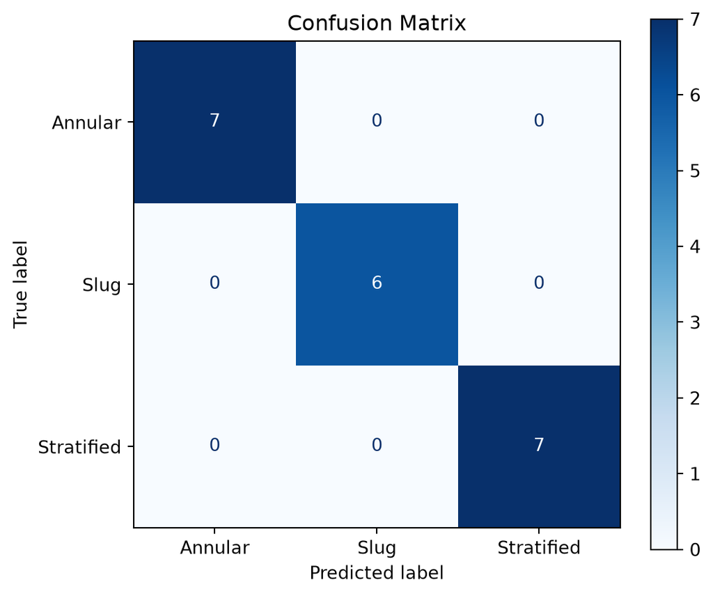

### Task 7 : Visualise the decision boundary

The clearest way to understand a two-feature classifier is to draw its **decision boundary**: the regions of feature space it assigns to each class. We do this by evaluating the model on a fine grid of points covering the plot, colouring each grid point by its predicted class, and then overlaying the real data. Write a function `plot_decision_boundary` that does this.

**TipThe NumPy helpers for building and evaluating a grid**

Drawing a decision boundary will require the following NumPy and Matplotlib helpers functions:

- [`np.meshgrid(xs, ys)`](https://numpy.org/doc/stable/reference/generated/numpy.meshgrid.html): turns those two 1D axes into a 2D grid of coordinates, `xx` and `yy`, covering the whole plot.
- [`.ravel()`](https://numpy.org/doc/stable/reference/generated/numpy.ravel.html): flattens the 2D `xx`/`yy` into 1D so every grid point can be fed to the model.
- [`np.c_[a, b]`](https://numpy.org/doc/stable/reference/generated/numpy.c_.html): stacks the two flattened arrays column-wise into the `(n, 2)` shape that `model.predict` expects.
- `.reshape(xx.shape)`: folds the 1D predictions back into the grid’s 2D shape so they can be plotted.
- [`plt.contourf(xx, yy, Z)`](https://matplotlib.org/stable/api/_as_gen/matplotlib.pyplot.contourf.html): fills each grid region with the colour of its predicted class.

```
plot_decision_boundary.py
```

```python
def plot_decision_boundary(model, X, y, class_names):
    """
    Plot the decision regions of a fitted two-feature classifier, with the data overlaid.

    Parameters
    ----------
    model : fitted scikit-learn classifier
        The trained model whose boundary is drawn.
    X : np.ndarray
        A 2D feature array (the same features the model was trained on).
    y : np.ndarray
        The integer-encoded labels.
    class_names : np.ndarray
        The text label for each class.

    Returns
    -------
    None
        Displays the decision boundary plot.
    """
```

plot_decision_boundary(lr_model, X_log, y, class_names)

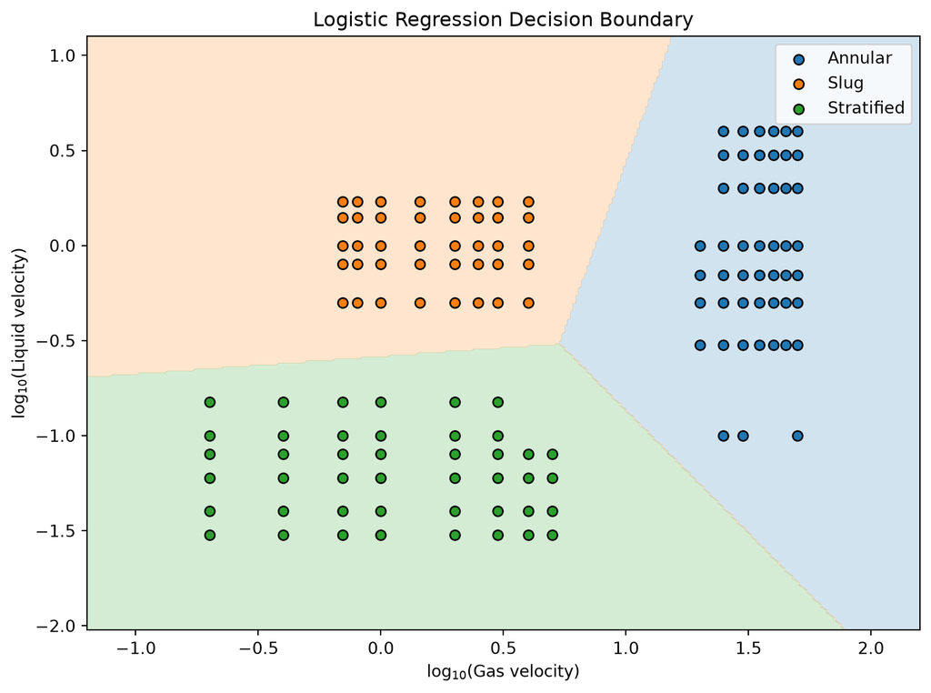

Notice that the boundaries between regions are **straight lines**; this is the defining feature of logistic regression. Because the classes separate so well in log-space, those straight lines are enough to classify every point correctly.

**Callout-answer**Answer**

```
plot_decision_boundary.py
```

```python
def plot_decision_boundary(model, X, y, class_names):
    """
    Plot the decision regions of a fitted two-feature classifier, with the data overlaid.

    Parameters
    ----------
    model : fitted scikit-learn classifier
        The trained model whose boundary is drawn.
    X : np.ndarray
        A 2D feature array (the same features the model was trained on).
    y : np.ndarray
        The integer-encoded labels.
    class_names : np.ndarray
        The text label for each class.

    Returns
    -------
    None
        Displays the decision boundary plot.
    """

    # Build a grid of points spanning the feature space
    x_min, x_max = X[:, 0].min() - 0.5, X[:, 0].max() + 0.5
    y_min, y_max = X[:, 1].min() - 0.5, X[:, 1].max() + 0.5
    xx, yy = np.meshgrid(np.linspace(x_min, x_max, 300),
                         np.linspace(y_min, y_max, 300))

    # Predict the class for every grid point
    Z = model.predict(np.c_[xx.ravel(), yy.ravel()]).reshape(xx.shape)

    plt.figure(figsize=(8, 6))
    plt.contourf(xx, yy, Z, alpha=0.2,
                 levels=np.arange(len(class_names) + 1) - 0.5,
                 colors=[f"C{i}" for i in range(len(class_names))])
    for i, name in enumerate(class_names):
        plt.scatter(X[y == i, 0], X[y == i, 1], color=f"C{i}", label=name, edgecolor="k")
    plt.xlabel("log$_{10}$(Gas velocity)")
    plt.ylabel("log$_{10}$(Liquid velocity)")
    plt.title("Logistic Regression Decision Boundary")
    plt.legend(loc='best')
    plt.tight_layout()
    plt.show()

plot_decision_boundary(lr_model, X_log, y, class_names)
```

Output

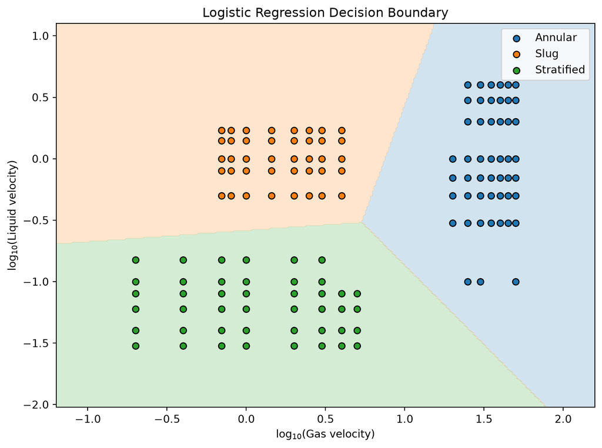

### Task 8 : Explore the regularisation strength `C`

Logistic regression has a hyperparameter `C` that controls **regularisation**, which penalises large model coefficients. A **small** `C` applies strong regularisation, producing a simpler model that may underfit the data. A **large** `C` applies weak regularisation, allowing the model to fit the training data more closely and potentially overfit.

Write a function `explore_C` that trains a logistic regression model for a range of `C` values and plots the resulting **training and validation accuracies**. Use the plot to compare how regularisation affects model fit and generalisation performance. Because `C` spans several orders of magnitude, use a **logarithmic x-axis**.

The example usage of the function is provided below, along with the output plot:

C_values = np.logspace(-3, 3, 20)

explore_C(X_train, y_train, X_val, y_val, C_values)

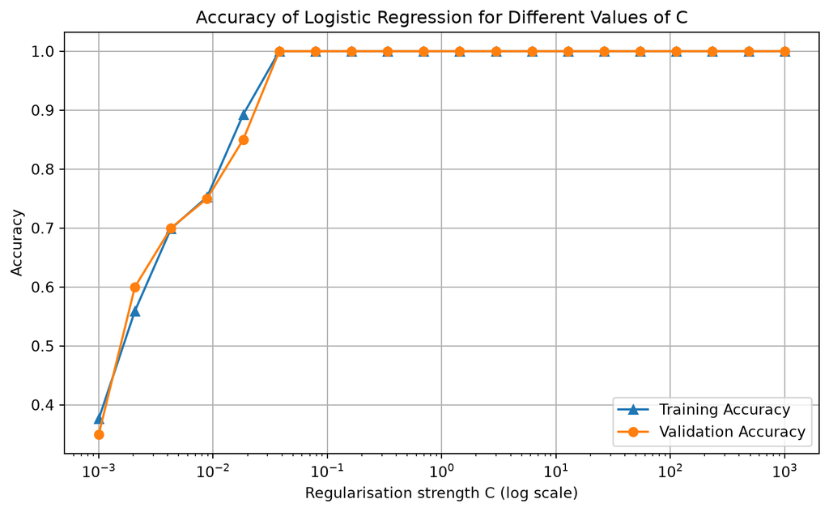

Looking at the plot, what happens to the training and validation accuracies when `C` is very small? Why does strong regularisation have this effect? Based on the plot, what is the smallest value of `C` that achieves the maximum test accuracy, and why might this be considered the optimal choice?

**Callout-answer**Answer**

```
explore_C.py
```

```python
def explore_C(X_train, y_train, X_val, y_val, C_values):
    """
    Evaluate logistic regression accuracy across a range of regularisation strengths.

    Parameters
    ----------
    X_train, y_train : np.ndarray
        The training features and labels.
    X_val, y_val : np.ndarray
        The validation features and labels.
    X_val : pd.DataFrame
        Validation features.
    y_val : pd.Series
        Validation labels.
    C_values : array-like
        The values of C to evaluate.

    Returns
    -------
    None
        Plots training and validation accuracy as a function of C.
    """


    accuracies_train = []
    accuracies_val = []
    for C in C_values:
        lr_model = LogisticRegression(C=C)
        lr_model.fit(X_train, y_train)
        accuracies_train.append(lr_model.score(X_train, y_train))
        accuracies_val.append(lr_model.score(X_val, y_val))

    fig, ax = plt.subplots(figsize=(8, 5))
    ax.plot(C_values, accuracies_train, marker='^',label='Training Accuracy')
    ax.plot(C_values, accuracies_val, marker='o',label='Validation Accuracy')
    ax.set_xscale('log')
    ax.set_title('Accuracy of Logistic Regression for Different Values of C')
    ax.set_xlabel('Regularisation strength C (log scale)')
    ax.set_ylabel('Accuracy')
    ax.grid(True)
    ax.legend(loc='best')
    plt.tight_layout()
    plt.show()

C_values = np.logspace(-3, 3, 20)
explore_C(X_train, y_train, X_val, y_val, C_values)
```

Output

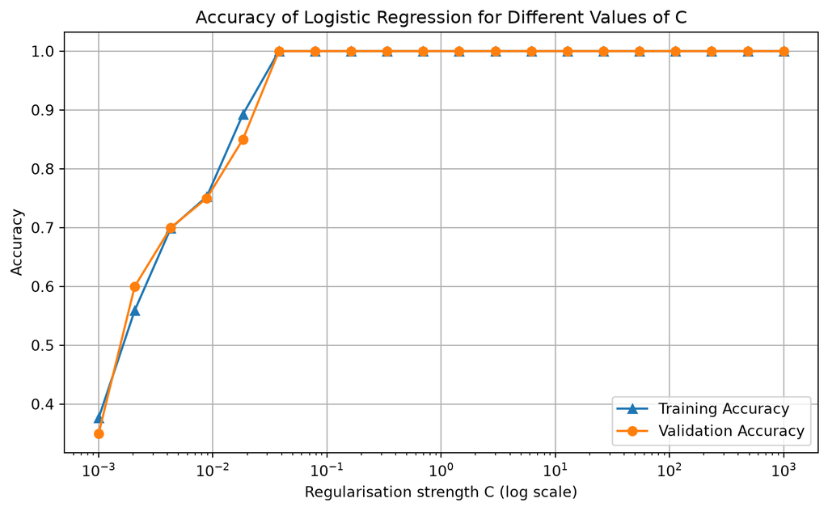

At very small values of `C`, regularisation is so strong that the model’s coefficients are heavily shrunk towards zero. As a result, the model cannot capture the patterns in the data effectively, leading to low training and validation accuracy. This is an example of **underfitting**.

As `C` increases, the regularisation penalty becomes weaker, allowing the model to learn a more appropriate decision boundary. Both training and validation accuracy increase rapidly and eventually reach 100%.

In this plot, the validation accuracy reaches its maximum at approximately `C ≈ 0.04` and remains unchanged for larger values of `C`. Since larger values of `C` do not improve performance, the smallest value that achieves the maximum validation accuracy is often considered the **optimal choice**, as it provides a simpler model with stronger regularisation.

Because this dataset appears to be cleanly separable, increasing `C` does not lead to a drop in validation accuracy. However, for noisier datasets, very large values of `C` can cause the model to overfit the training data, resulting in high training accuracy but lower validation accuracy.

### Task 9 : Test the Logistic Regression Classifier

Since a confusion matrix provides a detailed view of a classifier’s predictions, showing not only how many predictions were correct but also the types of mistakes that were made. From the confusion matrix, we can calculate additional metrics that provide a more complete evaluation of model performance.

Metrics such as **precision**, **recall**, and **F1-score** are often more informative than **accuracy** because they take different types of classification errors into account. These metrics help us understand how well the classifier distinguishes between the different flow regimes and whether some classes are more difficult to predict than others.

Write a function `evaluate_classifier` that calculates the precision, recall, and F1-score for a fitted classifier and displays the results. Use this function to evaluate the Logistic Regression model using the optimal value of `C` identified from the validation results.

**TipPerformance metrics**

The functions `precision_score`, `recall_score`, and `f1_score` are available from `sklearn.metrics`.

- **Precision** measures the proportion of predicted failures that were actually failures.
- **Recall** measures the proportion of actual failures that were correctly detected.
- **F1-score** balances precision and recall.

```
evaluate_classifier.py
```

```python
def evaluate_classifier(model, X_train, y_train, X_test, y_test):
    """
    Calculate classification metrics for the training
    and testing sets.

    Parameters
    ----------
    model : sklearn classifier
        A fitted classification model.
    X_train : pd.DataFrame
        Training features.
    y_train : pd.Series
        Training labels.
    X_test : pd.DataFrame
        Testing features.
    y_test : pd.Series
        Testing labels.

    Returns
    -------
    train_metrics : dict
        Dictionary containing the training-set metrics:
        "precision", "recall", and "f1_score".

    test_metrics : dict
        Dictionary containing the testing-set metrics:
        "precision", "recall", and "f1_score".
    """
    return train_metrics, test_metrics
```

```python
# Reuse the train_logistic_regression function with the optimal value of C
C=C_opt
lr_model, accuracy_train, accuracy_test = train_logistic_regression(X_train, y_train, X_test, y_test, C)

train_metrics, test_metrics = evaluate_classifier(lr_model, X_train, y_train, X_test, y_test)
print("Training Set")

print(train_metrics)

print("Testing Set")
print(test_metrics)
```

What does this tell you about the classifier’s performance?

**Callout-answer**Answer**

```
evaluate_classifier.py
```

```python
def evaluate_classifier(model, X_train, y_train, X_test, y_test):
    """
    Calculate classification metrics for the training
    and testing sets.

    Parameters
    ----------
    model : sklearn classifier
        A fitted classification model.
    X_train : pd.DataFrame
        Training features.
    y_train : pd.Series
        Training labels.
    X_test : pd.DataFrame
        Testing features.
    y_test : pd.Series
        Testing labels.

    Returns
    -------
    train_metrics : dict
        Dictionary containing the training-set metrics:
        "precision", "recall", and "f1_score".

    test_metrics : dict
        Dictionary containing the testing-set metrics:
        "precision", "recall", and "f1_score".
    """

    # Training predictions
    y_pred_train = model.predict(X_train)

    # For multiclass classification, use a weighted average across all classes
    train_precision = precision_score(y_train, y_pred_train, average="weighted")
    train_recall = recall_score(y_train, y_pred_train, average="weighted")
    train_f1 = f1_score(y_train, y_pred_train, average="weighted")

    # Testing predictions
    y_pred_test = model.predict(X_test)

    test_precision = precision_score(y_test, y_pred_test, average="weighted")
    test_recall = recall_score(y_test, y_pred_test, average="weighted")
    test_f1 = f1_score(y_test, y_pred_test, average="weighted")

    train_metrics = {
        "precision": train_precision,
        "recall": train_recall,
        "f1_score": train_f1
    }

    test_metrics = {
        "precision": test_precision,
        "recall": test_recall,
        "f1_score": test_f1
    }

    return train_metrics, test_metrics

# Reuse the train_logistic_regression function with the optimal value of C
C=0.04
lr_model, accuracy_train, accuracy_test = train_logistic_regression(X_train, y_train, X_test, y_test, C)
print(f"Logistic regression training accuracy: {accuracy_train:.4f}")
print(f"Logistic regression testing accuracy: {accuracy_test:.4f}")

train_metrics, test_metrics = evaluate_classifier(lr_model, X_train, y_train, X_test, y_test)

print("Training metrics")
print(train_metrics)

print("Testing metrics")
print(test_metrics)
```

Output

```
Logistic regression training accuracy: 1.0000
Logistic regression testing accuracy: 1.0000
Training metrics
{'precision': 1.0, 'recall': 1.0, 'f1_score': 1.0}
Testing metrics
{'precision': 1.0, 'recall': 1.0, 'f1_score': 1.0}
```

## Part B: Support Vector Machines for Fault Detection

An **evaporator** is a unit operation used to increase the concentration of a solution by boiling off solvent. In this part, we will analyse data from a simulated **Newell-Lee forced-circulation evaporator**, a benchmark process widely used in studies of process control, monitoring, and fault detection.

As shown in Figure 2, feed enters the evaporator (E-101), where steam provides the heat required to vaporise solvent and increase the product composition from $X_1= 5\%$ to $X_2= 25\%$. The vapour stream passes through a separator and condenser before leaving the system, while a circulation pump recycles liquid through the evaporator. During normal operation, the separator liquid level ($L_2$) is maintained at $1\,\text{m}$ and the separator pressure ($P_2$) is maintained at $50.5\,\text{kPa}$.

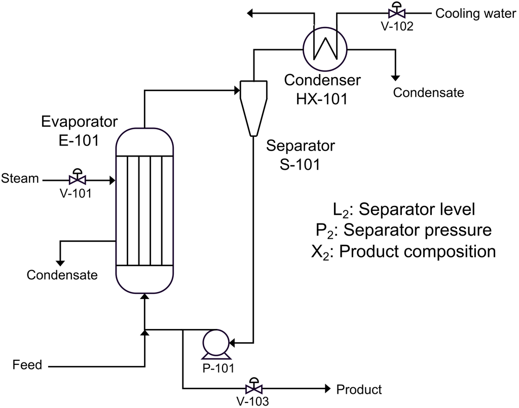

Figure 2: Schematic of the evaporator-separator process showing the main equipment and measured variables ($L_2$, $P_2$, and $X_2$).

The dataset contains time-series measurements collected under both **normal operating conditions** and during a **pump failure** event. A pump failure disrupts liquid circulation through the evaporator, causing changes in process behaviour that may affect both system stability and product quality. Our goal is to use the measured process variables to determine whether the plant is operating normally or experiencing a pump failure.

Download the dataset below to get started.

```
evap_data.csv
```

```
L2,P2,X2,Status
1.044822916,50.39874027,27.08635423,Normal
1.008144051,50.27810345,22.92532847,Normal
1.020358578,51.45807588,26.58529487,Normal
0.97448334,50.50077586,24.56927528,Normal
... (998 more lines)
```

Below is an description of each of the varaibles in the dataset:

| Feature | Description |
| --- | --- |
| L2 | Separator liquid level [m] |
| P2 | Operating pressure [kPa] |
| X2 | Product composition [%] |
| Status | Operating status: Normal or Pump_failure (**the label**) |

**NoteHow does a support vector machine work?**

An SVM looks for the decision boundary (a *hyperplane*) that separates the classes with the **widest possible margin**: the largest gap on either side before hitting a data point. The points sitting on the edge of that margin are the **support vectors**, and they alone define the boundary; moving any other point does not change it. A **soft margin**, controlled by the hyperparameter `C`, allows a few points to fall inside the margin or on the wrong side, trading a little training accuracy for a simpler, more general boundary.

When the classes cannot be separated by a straight line, the **kernel trick** implicitly maps the data into a higher-dimensional space where a linear boundary *does* exist. The `rbf` (radial basis function) and `poly` (polynomial) kernels do exactly this, producing **curved** boundaries in the original feature space, whereas the `linear` kernel keeps the boundary straight.

### Task 10 : Load the dataset

Write a function `load_evap_data` that mirrors the loader from Part A: it should return the three features as `X`, the integer-encoded `Status` as `y`, and the class names, printing the shapes to confirm the data loaded correctly.

X, y, class_names = load_evap_data('data/evap_data.csv')

Features shape: (1001, 3)

Labels shape: (1001,)

Classes: ['Normal', 'Pump_failure']

**Note**

We deliberately reuse the same variable names (`X`, `y`, `class_names`, `X_train`, …) for this new dataset; everything from Part A has served its purpose, and this keeps the code familiar.

**Callout-answer**Answer**

```
load_evap_data.py
```

```python
def load_evap_data(file_path):
    """
    Load the evaporator dataset and return the features, encoded labels,
    and class names.

    Parameters
    ----------
    file_path : str
        Path to the CSV file containing the evaporator dataset.

    Returns
    -------
    X : pd.DataFrame
        DataFrame containing the input features used for fault
        classification.

    y : pd.Series
        Array containing the status labels encoded as integers.

    class_names : np.ndarray
        Array containing the original status class names corresponding
        to the encoded labels (e.g., Normal, Pump_failure).

    """
    # Load the dataset
    data = pd.read_csv(file_path)

    # Features
    X = data.iloc[:, :3]

    # Labels: status encoded as integers
    encoder = LabelEncoder()
    y = pd.Series(encoder.fit_transform(data["Status"]))
    class_names = encoder.classes_

    print(f"Features shape: {X.shape}")
    print(f"Labels shape: {y.shape}")
    print(f"Classes: {list(class_names)}")
    return X, y, class_names

X, y, class_names = load_evap_data('data/evap_data.csv')
```

Output

```
Features shape: (1001, 3)
Labels shape: (1001,)
Classes: ['Normal', 'Pump_failure']
```

### Task 11 : Explore the dataset

Write a function `explore_evap_data` that prints the summary statistics of the three features and the number of samples in each class, and then draws a scatter plot of two of the features (`P2` against `X2`) coloured by status. This gives us a first look at how separable the two classes are.

explore_evap_data(X, y, class_names)

First 5 rows of features:

L2 P2 X2

0 1.044823 50.398740 27.086354

1 1.008144 50.278103 22.925328

2 1.020359 51.458076 26.585295

3 0.974483 50.500776 24.569275

4 1.044522 50.482284 23.723251

First 5 rows of labels:

0 0

1 0

2 0

3 0

4 0

dtype: int64

Summary statistics of features:

L2 P2 X2

count 1001.000000 1001.000000 1001.000000

mean 1.225381 44.173590 20.860839

std 0.413174 7.542502 7.827228

min 0.631431 30.353787 10.054981

25% 0.828389 37.563176 13.712045

50% 1.173788 48.336133 19.659249

75% 1.528196 50.587155 27.801657

max 2.048763 54.331394 40.119300

Label distribution:

1 501

0 500

Name: count, dtype: int64

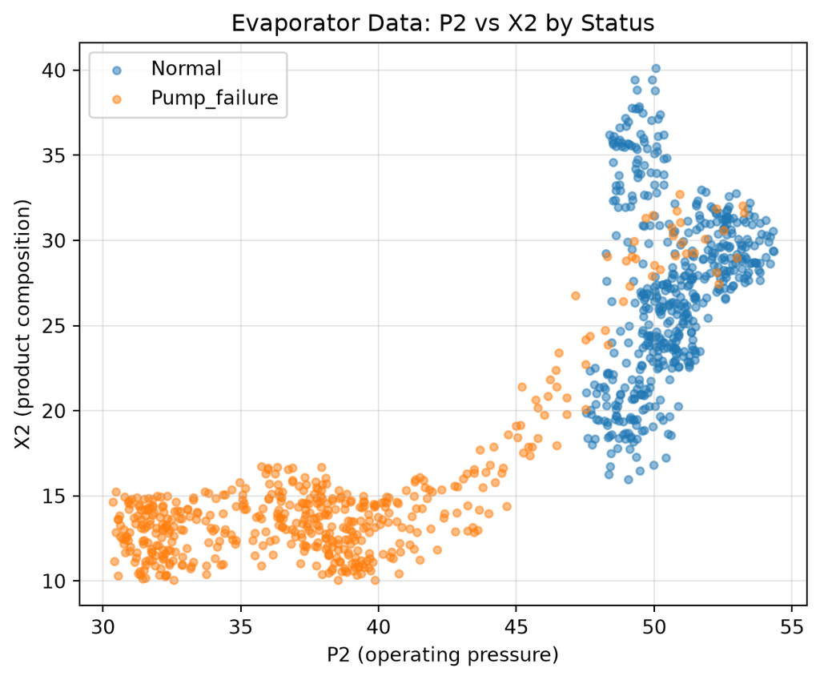

The two classes form fairly distinct clusters, though they meet in the middle, a good candidate for an SVM.

**Callout-answer**Answer**

```
explore_evap_data.py
```

```python
def explore_evap_data(X, y, class_names):
    """
    Explore the evaporator dataset by displaying sample data,
    summary statistics, label distribution, and a scatter plot
    of P2 versus X2 coloured by status.

    Parameters
    ----------
    X : pd.DataFrame
        DataFrame containing the input features (L2, P2, X2).

    y : np.ndarray or pd.Series
        Encoded status labels.

    class_names : np.ndarray
        Names of the status classes corresponding to the encoded labels.

    Returns
    -------
    None
        Prints dataset information and displays a scatter plot.
    """
    print("First 5 rows of features:")
    print(X.head())
    print("First 5 rows of labels:")
    print(y.head())
    print("Summary statistics of features:")
    print(X.describe())
    print("Label distribution:")
    print(y.value_counts())

    # Scatter plot of P2 vs X2, coloured by status
    plt.figure(figsize=(6, 5))
    for i, name in enumerate(class_names):
        plt.scatter(X.values[y == i, 1], X.values[y == i, 2], color=f"C{i}", label=name, alpha=0.5, s=15)
    plt.xlabel("P2 (operating pressure)")
    plt.ylabel("X2 (product composition)")
    plt.title("Evaporator Data: P2 vs X2 by Status")
    plt.legend(loc="best")
    plt.grid(True, alpha=0.3)
    plt.tight_layout()
    plt.show()

explore_evap_data(X, y, class_names)
```

Output

```
First 5 rows of features:
         L2         P2         X2
0  1.044823  50.398740  27.086354
1  1.008144  50.278103  22.925328
2  1.020359  51.458076  26.585295
3  0.974483  50.500776  24.569275
4  1.044522  50.482284  23.723251
First 5 rows of labels:
0    0
1    0
2    0
3    0
4    0
dtype: int64
Summary statistics of features:
                L2           P2           X2
count  1001.000000  1001.000000  1001.000000
mean      1.225381    44.173590    20.860839
std       0.413174     7.542502     7.827228
min       0.631431    30.353787    10.054981
25%       0.828389    37.563176    13.712045
50%       1.173788    48.336133    19.659249
75%       1.528196    50.587155    27.801657
max       2.048763    54.331394    40.119300
Label distribution:
1    501
0    500
Name: count, dtype: int64
```

Output

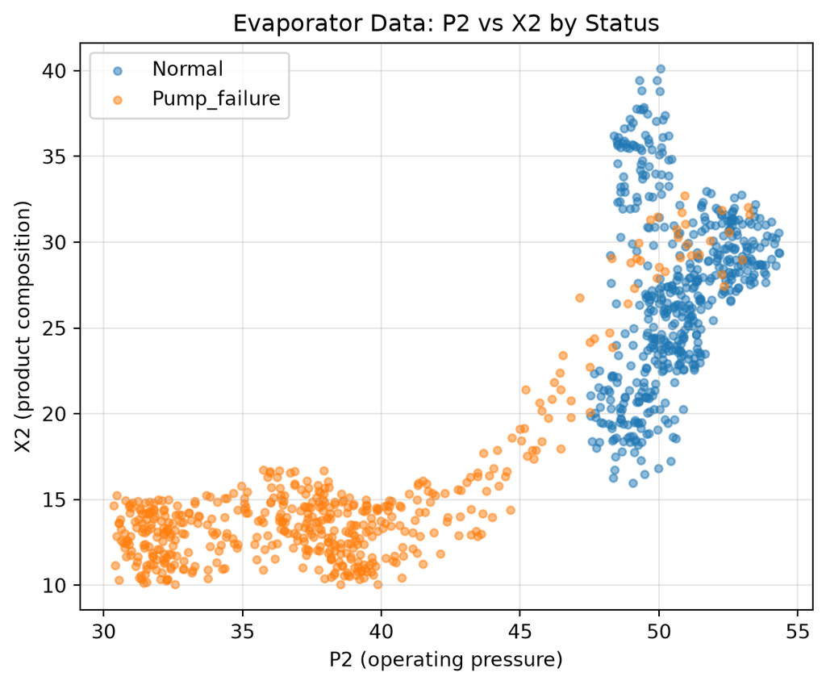

### Task 12 : Split into training, validation and testing sets

Reuse the `preprocess_data` function developed in Part A to split the features and labels into **training**, **validation**, and **testing** sets. As before, use a 70% training split, followed by a 15% validation split and a 15% testing split. Use a `random_state` of `42` and stratify the splits to preserve the class distribution across all subsets. ``

X_train, X_val, X_test, y_train, y_val, y_test = preprocess_data(X, y)

X_train.shape, X_val.shape, X_test.shape, y_train.shape, y_val.shape, y_test.shape

((700, 3), (150, 3), (151, 3), (700,), (150,), (151,))

**Callout-answer**Answer**

```
preprocess_data.py
```

```python
def preprocess_data(X, y, temp_size=0.3, test_size=0.50, random_state=42):
    """
    Preprocess the dataset by splitting into training, validation,
    and testing sets.

    Parameters
    ----------
    X : pd.DataFrame
        A Pandas DataFrame containing the features (input variables).
    y : pd.Series
        A Pandas Series containing the labels (output variable).
    train_size : float, optional
        The proportion of the dataset to include in the training set
        (default is 0.70).
    temp_size : float, optional
        The proportion of the dataset to reserve for validation and
        testing (default is 0.30).
    test_size : float, optional
        The proportion of the temporary data to include in the test set
        (default is 0.50, resulting in a 15% test set and 15% validation set).
    random_state : int, optional
        The random seed for reproducibility (default is 42).

    Returns
    -------
    X_train : pd.DataFrame
        Training features.
    X_val : pd.DataFrame
        Validation features.
    X_test : pd.DataFrame
        Testing features.
    y_train : pd.Series
        Training labels.
    y_val : pd.Series
        Validation labels.
    y_test : pd.Series
        Testing labels.
    """

    # Split the dataset into a training set (70%) and a temporary set (30%)
    X_train, X_temp, y_train, y_temp = train_test_split(X, y, test_size=temp_size,stratify=y, random_state=random_state)

    # Split the temporary set equally into validation (15%) and testing (15%)
    X_val, X_test, y_val, y_test = train_test_split(X_temp, y_temp, test_size=test_size,stratify=y_temp, random_state=random_state)

    return X_train, X_val, X_test, y_train, y_val, y_test

X_train, X_val, X_test, y_train, y_val, y_test = preprocess_data(X, y)
X_train.shape, X_val.shape, X_test.shape, y_train.shape, y_val.shape, y_test.shape
```

Output

```
((700, 3), (150, 3), (151, 3), (700,), (150,), (151,))
```

### Task 13 : Scale the features

Reuse the training, validation, and testing splits created previously. Write a function `scale_features` that standardises the features using `StandardScaler`.

Fit the scaler on the **training set only**, then use the fitted scaler to transform the training, validation, and testing sets. This prevents information from the validation and testing sets from leaking into the model during training.

There are several approaches to feature scaling. In this tutorial, we use **standardisation** (`StandardScaler`), which rescales each feature so that it has a mean of 0 and a standard deviation of 1. Other common methods include **min-max scaling** (`MinMaxScaler`), which rescales features to a specified range (typically 0 to 1), and **max-absolute scaling** (`MaxAbsScaler`), which rescales features by dividing by the largest absolute value observed for each feature. For a more detailed discussion of these methods and when to use them, refer to the **Week 1 materials**.

**Tip`fit_transform` vs `transform`**

`StandardScaler` provides two methods that serve different purposes.

- Use `scaler.fit_transform(X_train)` on the **training** data. This learns the mean and standard deviation of each feature and applies the scaling.
- Use `scaler.transform(X_val)` and `scaler.transform(X_test)` on the **validation** and **testing** data. This applies the same scaling learned from the training set.

Never call `fit` or `fit_transform` on the validation or testing sets, as this would introduce data leakage and lead to overly optimistic performance estimates. See the `StandardScaler` [docs](https://scikit-learn.org/stable/modules/generated/sklearn.preprocessing.StandardScaler.html).

```
scale_features.py
```

```python
def scale_features(X_train, X_val, X_test):
    """
    Standardise the training, validation, and testing features.

    Parameters
    ----------
    X_train : pd.DataFrame
        Training features.
    X_val : pd.DataFrame
        Validation features.
    X_test : pd.DataFrame
        Testing features.

    Returns
    -------
    X_train : np.ndarray
        Scaled training features.
    X_val : np.ndarray
        Scaled validation features.
    X_test : np.ndarray
        Scaled testing features.
    """
    return X_train, X_val, X_test
```

X_train, X_val, X_test, y_train, y_val, y_test = preprocess_data(X, y)

X_train, X_val, X_test = scale_features(X_train, X_val, X_test)

X_train.shape, X_val.shape, X_test.shape, y_train.shape, y_val.shape, y_test.shape

((700, 3), (150, 3), (151, 3), (700,), (150,), (151,))

**ImportantWhy scale the features for an SVM?**

An SVM cares about **distances** between points: directly for the `rbf` kernel, and through the margin for every kernel. If one feature ranged over 0–1000 and another over 0–1, the first would dominate every distance and the model would effectively ignore the second. Standardising each feature to zero mean and unit variance puts them on an equal footing. (This is why scaling mattered far less for logistic regression in Part A, where both log-velocity features were already comparable.)

**Callout-answer**Answer**

```
scale_features.py
```

```python
def scale_features(X_train, X_val, X_test):
    """
    Standardise the training, validation, and testing features.

    Parameters
    ----------
    X_train : pd.DataFrame
        Training features.
    X_val : pd.DataFrame
        Validation features.
    X_test : pd.DataFrame
        Testing features.

    Returns
    -------
    X_train : np.ndarray
        Scaled training features.
    X_val : np.ndarray
        Scaled validation features.
    X_test : np.ndarray
        Scaled testing features.
    """

    # Fit the scaler on the training data only
    scaler = StandardScaler()
    X_train = scaler.fit_transform(X_train)

    # Apply the same scaling to the validation and testing data
    X_val = scaler.transform(X_val)
    X_test = scaler.transform(X_test)

    return X_train, X_val, X_test

X_train, X_val, X_test, y_train, y_val, y_test = preprocess_data(X, y)
X_train, X_val, X_test = scale_features(X_train, X_val, X_test)
X_train.shape, X_val.shape, X_test.shape, y_train.shape, y_val.shape, y_test.shape
```

Output

```
((700, 3), (150, 3), (151, 3), (700,), (150,), (151,))
```

### Task 14 : Train a support vector machine

Write a function `train_svm` that trains a support vector classifier (`SVC`) on the training data, evaluates its accuracy on the validation set, and returns both the model and the accuracy. Expose the `kernel`, `C`, and `gamma` settings as arguments so we can experiment with them, and start with a **linear** kernel.

```
train_svm.py
```

```python
def train_svm(X_train, y_train, X_val, y_val,
              kernel="linear", C=1.0, gamma="scale"):
    """
    Train a support vector classifier and evaluate it on the validation set.

     Parameters
    ----------
    X_train : np.ndarray
        Training features.
    y_train : np.ndarray
        Training labels.
    X_val : np.ndarray
        Validation features.
    y_val : np.ndarray
        Validation labels.
    kernel : str, optional
        The SVM kernel: "linear", "rbf", or "poly" (default is "linear").
    C : float, optional
        The soft-margin regularisation strength (default is 1.0).
    gamma : str or float, optional
        The kernel coefficient for "rbf" and "poly" kernels
        (default is "scale").

    Returns
    -------
    model : SVC
        The trained support vector classifier.
    accuracy_train : float
        Accuracy score on the training set.
    accuracy_val : float
        Accuracy score on the validation set.
    """

    return model, accuracy_train, accuracy_val
```

svm_model, accuracy_train, accuracy_val = train_svm(X_train, y_train, X_val, y_val, kernel="linear")

print(f"Linear SVM training accuracy: {accuracy_train:.4f}")

Linear SVM training accuracy: 0.9857

print(f"Linear SVM validation accuracy: {accuracy_val:.4f}")

Linear SVM validation accuracy: 0.9667

**Callout-answer**Answer**

```
train_svm.py
```

```python
def train_svm(X_train, y_train, X_val, y_val,
              kernel="linear", C=1.0, gamma="scale"):
    """
    Train a support vector classifier and evaluate it on the validation set.

     Parameters
    ----------
    X_train : np.ndarray
        Training features.
    y_train : np.ndarray
        Training labels.
    X_val : np.ndarray
        Validation features.
    y_val : np.ndarray
        Validation labels.
    kernel : str, optional
        The SVM kernel: "linear", "rbf", or "poly" (default is "linear").
    C : float, optional
        The soft-margin regularisation strength (default is 1.0).
    gamma : str or float, optional
        The kernel coefficient for "rbf" and "poly" kernels
        (default is "scale").

    Returns
    -------
    model : SVC
        The trained support vector classifier.
    accuracy_train : float
        Accuracy score on the training set.
    accuracy_val : float
        Accuracy score on the validation set.
    """

    # Create an SVM classifier with the specified hyperparameters
    model = SVC(kernel=kernel, C=C, gamma=gamma)

    # Train the classifier on the training data
    model.fit(X_train, y_train)

    # Evaluate the accuracy on the training set
    accuracy_train = model.score(X_train, y_train)

    # Evaluate the accuracy on the validation set
    accuracy_val = model.score(X_val, y_val)

    return model, accuracy_train, accuracy_val

svm_model, accuracy_train, accuracy_val = train_svm(X_train, y_train, X_val, y_val, kernel="linear")
print(f"Linear SVM training accuracy: {accuracy_train:.4f}")
print(f"Linear SVM validation accuracy: {accuracy_val:.4f}")
```

Output

```
Linear SVM training accuracy: 0.9857
Linear SVM validation accuracy: 0.9667
```

### Task 15 : Compare kernels

The real flexibility of an SVM comes from its **kernel**. Write a function `compare_kernels` that trains an SVM with each kernel in a supplied list, prints the validation accuracy of each, and draws a bar chart comparing them.

kernels = ["linear", "rbf", "poly"]

compare_kernels(X_train, y_train, X_val, y_val, kernels)

linear kernel: accuracy_train = 0.9857

linear kernel: accuracy_val = 0.9667

rbf kernel: accuracy_train = 0.9857

rbf kernel: accuracy_val = 0.9733

poly kernel: accuracy_train = 0.9857

poly kernel: accuracy_val = 0.9733

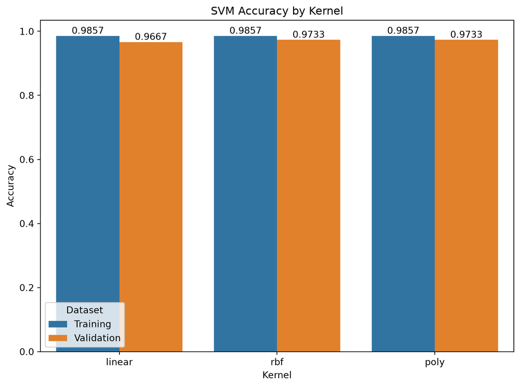

All three kernels achieve very similar accuracy here. What does that tell you about how separable the two classes are, and which kernel would you choose?

**Callout-answer**Answer**

```
compare_kernels.py
```

```python
def compare_kernels(X_train, y_train, X_val, y_val, kernels):
    """
    Train an SVM using different kernel functions and compare their
    training and validation accuracy.

    Parameters
    ----------
    X_train, y_train : np.ndarray
        Training feature matrix and labels.

    X_val, y_val : np.ndarray
        Validation feature matrix and labels.

    kernels : list of str
        List of kernels to evaluate (e.g., ["linear", "rbf", "poly"]).
    """

    # Store the training and validation accuracies for each kernel.
    accuracies_train = []
    accuracies_val = []

    # Train an SVM with each kernel and record its performance.
    for kernel in kernels:
        model, accuracy_train, accuracy_val = train_svm(
            X_train, y_train, X_val, y_val, kernel=kernel)

        accuracies_train.append(accuracy_train)
        accuracies_val.append(accuracy_val)

        print(f"{kernel:>8} kernel: accuracy_train = {accuracy_train:.4f}")
        print(f"{kernel:>8} kernel: accuracy_val  = {accuracy_val:.4f}")

    # Create a DataFrame in long format for seaborn.
    # Each kernel will have two bars: one for training accuracy
    # and one for validation accuracy.
    results = pd.DataFrame({
        "Kernel": kernels * 2,
        "Accuracy": accuracies_train + accuracies_val,
        "Dataset": ["Training"] * len(kernels) +
                   ["Validation"] * len(kernels)
    })

    # Plot training and validation accuracy for each kernel.
    plt.figure(figsize=(8, 6))
    ax = sns.barplot(data=results, x="Kernel",y="Accuracy",hue="Dataset")

    # Display the accuracy value above each bar.
    for container in ax.containers:
        ax.bar_label(container, fmt="%.4f")

    plt.xlabel("Kernel")
    plt.ylabel("Accuracy")
    plt.title("SVM Accuracy by Kernel")
    plt.tight_layout()
    plt.show()

kernels = ["linear", "rbf", "poly"]
compare_kernels(X_train, y_train, X_val, y_val, kernels)
```

Output

```
  linear kernel: accuracy_train = 0.9857
  linear kernel: accuracy_val  = 0.9667
     rbf kernel: accuracy_train = 0.9857
     rbf kernel: accuracy_val  = 0.9733
    poly kernel: accuracy_train = 0.9857
    poly kernel: accuracy_val  = 0.9733
```

Output

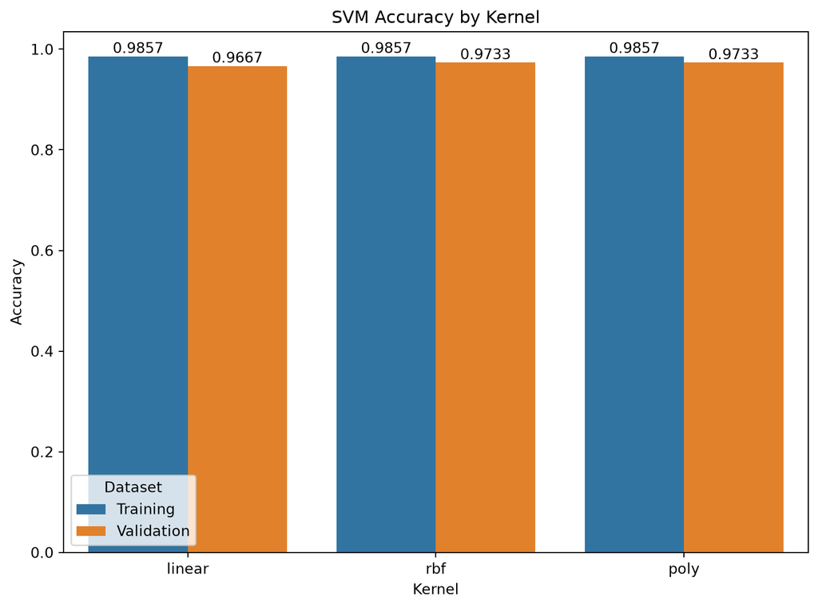

The kernels perform almost identically because the two classes are **very nearly linearly separable**: a straight boundary already gets almost everything right, so the extra flexibility of the `rbf` and `poly` kernels buys nothing. When several models tie, prefer the **simplest** one: the linear kernel is fastest and least prone to overfitting. A curved kernel like `rbf` only pays off when the true boundary between the classes is itself curved.

### Task 16 : Evaluate with a confusion matrix

For a fault-detection problem, the *type* of error matters: a missed pump failure (a false negative) is very different from a false alarm (a false positive). Reuse the `plot_confusion_matrix` function you wrote in Part A (it works with any fitted scikit-learn classifier) to inspect the errors made by the **final linear SVM model on the testing set**.

The testing set is used because it provides an unbiased assessment of how the selected model is likely to perform on new, unseen data. By examining the confusion matrix, we can identify which classes are most frequently misclassified and determine whether the model is making more false positives or false negatives.

```python
kernel=kernel_opt
svm_model, accuracy_train, accuracy_test = train_svm(X_train, y_train, X_test, y_test, kernel=kernel)
```

plot_confusion_matrix(svm_model, X_test, y_test, class_names)

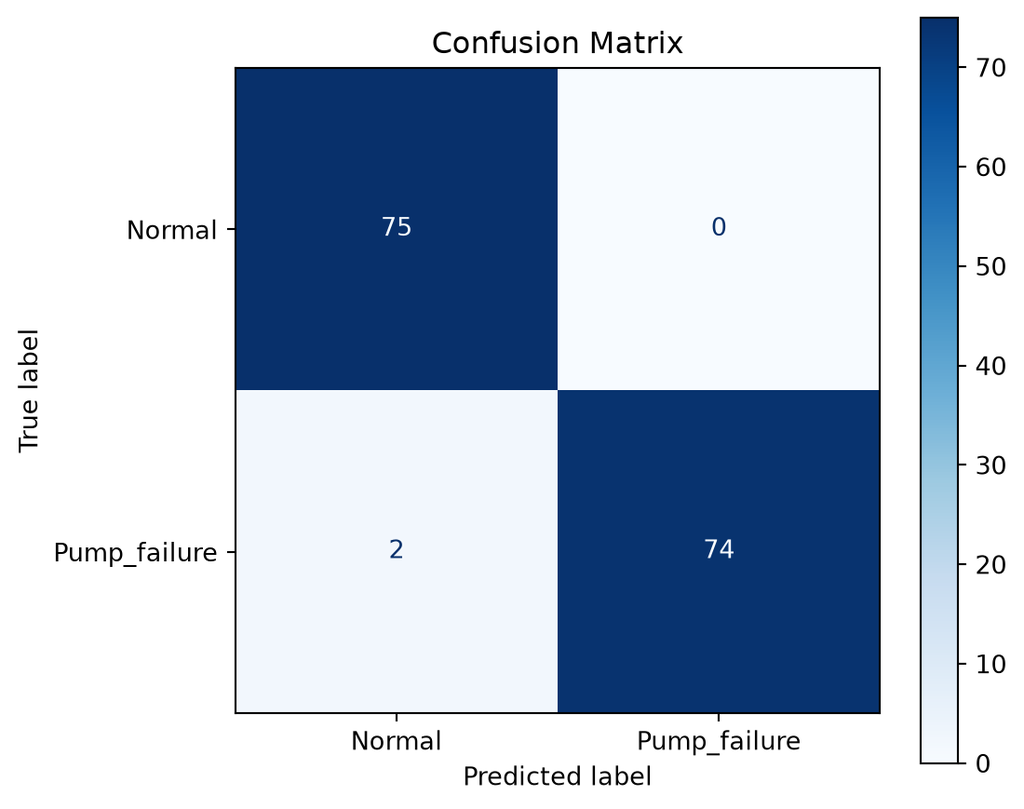

**NoteFalse positives vs false negatives**

In a binary fault-detection setting the off-diagonal entries have names:

- A **false negative** (a real `Pump_failure` predicted as `Normal`) means a genuine fault went undetected, usually the more dangerous error.
- A **false positive** (a `Normal` case flagged as `Pump_failure`) is a false alarm: annoying and costly, but safer.

Which of these would you be more willing to tolerate on a real plant? The answer shapes how you would tune the model.

**Callout-answer**Answer**

```python
# Reuses plot_confusion_matrix from Part A, no need to rewrite it.
kernel="linear"
svm_model, accuracy_train, accuracy_test = train_svm(X_train, y_train, X_test, y_test, kernel=kernel)
plot_confusion_matrix(svm_model, X_test, y_test, class_names)
```

Output

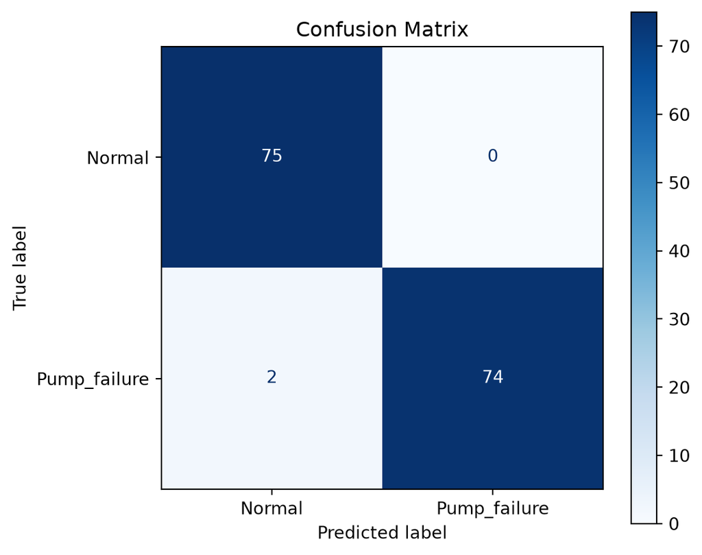

### Task 17 : Test the SVM Classifier

Reuse the `evaluate_classifier` function from Part A to calculate the precision, recall, and F1-score for the training and testing sets of the fault-detection problem.

```python
# Reuse the train_svm function with the optimal value of kernel
kernel=kernel_opt
svm_model, accuracy_train, accuracy_val = train_svm(X_train, y_train, X_test, y_test, kernel=kernel)

train_metrics, test_metrics = evaluate_classifier(svm_model, X_train, y_train, X_test, y_test)
print("Training Set")
print(train_metrics)

print("Testing Set")
print(test_metrics)
```

What does this tell you about the classifier’s performance?

**Callout-answer**Answer**

```
evaluate_classifier.py
```

```python
def evaluate_classifier(model, X_train, y_train, X_test, y_test):
    """
    Calculate classification metrics for the training
    and testing sets.

    Parameters
    ----------
    model : sklearn classifier
        A fitted classification model.
    X_train : pd.DataFrame
        Training features.
    y_train : pd.Series
        Training labels.
    X_test : pd.DataFrame
        Testing features.
    y_test : pd.Series
        Testing labels.

    Returns
    -------
    train_metrics : dict
        Dictionary containing the training-set metrics:
        "precision", "recall", and "f1_score".

    test_metrics : dict
        Dictionary containing the testing-set metrics:
        "precision", "recall", and "f1_score".
    """

    # Training predictions
    y_pred_train = model.predict(X_train)

    train_precision = precision_score(y_train, y_pred_train, average="weighted")
    train_recall = recall_score(y_train, y_pred_train, average="weighted")
    train_f1 = f1_score(y_train, y_pred_train, average="weighted")

    # Testing predictions
    y_pred_test = model.predict(X_test)

    test_precision = precision_score(y_test, y_pred_test, average="weighted")
    test_recall = recall_score(y_test, y_pred_test, average="weighted")
    test_f1 = f1_score(y_test, y_pred_test, average="weighted")

    train_metrics = {
        "precision": train_precision,
        "recall": train_recall,
        "f1_score": train_f1}

    test_metrics = {
        "precision": test_precision,
        "recall": test_recall,
        "f1_score": test_f1}

    return train_metrics, test_metrics

# Reuse the train_svm function with the optimal value of kernel
kernel_opt="linear"
svm_model, accuracy_train, accuracy_val = train_svm(X_train, y_train, X_test, y_test, kernel=kernel)
train_metrics, test_metrics = evaluate_classifier(svm_model, X_train, y_train, X_test, y_test)

print("Training Set")
print(train_metrics)

print("Testing Set")
print(test_metrics)
```

Output

```
Training Set
{'precision': 0.9861111111111112, 'recall': 0.9857142857142858, 'f1_score': 0.9857113696672789}
Testing Set
{'precision': 0.9870989937215102, 'recall': 0.9867549668874173, 'f1_score': 0.9867538050424073}
```

The precision, recall, and F1-score are all very high for both the training and testing sets, indicating that the classifier is highly effective at distinguishing between normal operation and pump failures. The high precision suggests that very few normal cases are incorrectly classified as failures, while the high recall indicates that very few actual pump failures are missed. The F1-score confirms a strong balance between precision and recall. Since the training and testing metrics are very similar, there is little evidence of overfitting, suggesting that the model generalises well to unseen data.

### Task 18 : Visualise the decision boundary and support vectors

Finally, let us *see* the SVM at work. Our model uses all three features, which we cannot draw, so to visualise the boundary we train a **separate** SVM on just two features, `P2` and `X2`, and plot its decision regions, overlaying the training data and circling the **support vectors**. Write a function `plot_svm_decision_boundary` that does this, using an `rbf` kernel so we can see a curved boundary.

**TipFinding the support vectors**

Once an `SVC` is fitted, its support vectors are stored on the model as the attribute `model.support_vectors_`; an array of their coordinates. Scatter these on top of the plot (for example as open circles, using `facecolors="none"`) to highlight the handful of points that actually define the boundary. The grid-plotting helpers (`np.meshgrid`, `.ravel()`, `np.c_`, `plt.contourf`) are the same ones introduced in the Part A decision-boundary task. See the documentation for more: [scikit-learn](https://scikit-learn.org/stable/modules/generated/sklearn.svm.SVC.html).

plot_svm_decision_boundary(X_train, y_train, class_names)

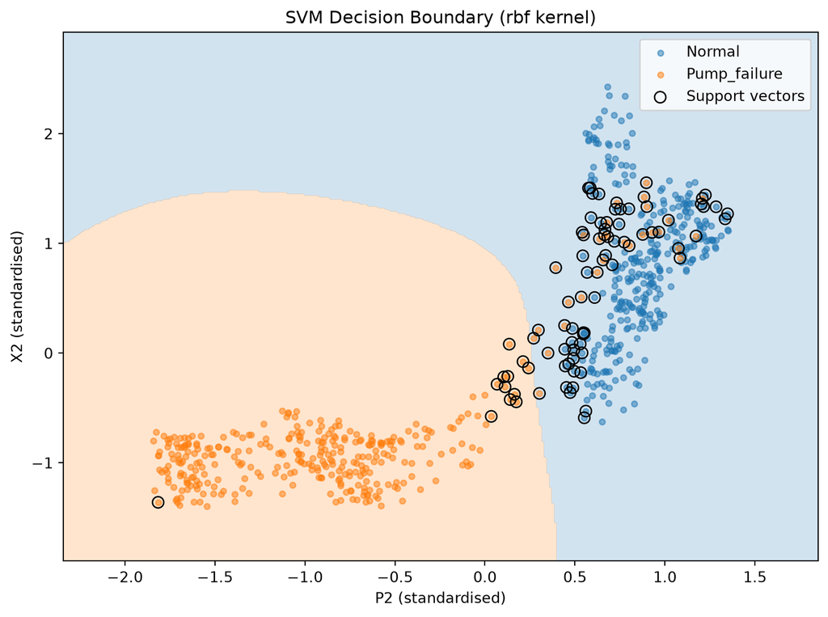

**Callout-answer**Answer**

```
plot_svm_decision_boundary.py
```

```python
def plot_svm_decision_boundary(X_train, y_train, class_names,
                               feature_idx=(1, 2), feature_names=("P2", "X2"), kernel="rbf"):
    """
    Train a two-feature SVM and plot its decision regions with the support vectors circled.

    Parameters
    ----------
    X_train : np.ndarray
        The (scaled) training features.
    y_train : np.ndarray
        The training labels.
    class_names : np.ndarray
        The text label for each class.
    feature_idx : tuple of int, optional
        Which two feature columns to use (default (1, 2) = P2 and X2).
    feature_names : tuple of str, optional
        Display names for the two chosen features.
    kernel : str, optional
        The SVM kernel to use for the plot (default "rbf").
    """
    # Train a fresh SVM on just the two chosen features
    X2d = X_train[:, feature_idx]
    model = SVC(kernel=kernel).fit(X2d, y_train)

    # Build a grid and predict the class at every grid point
    x_min, x_max = X2d[:, 0].min() - 0.5, X2d[:, 0].max() + 0.5
    y_min, y_max = X2d[:, 1].min() - 0.5, X2d[:, 1].max() + 0.5
    xx, yy = np.meshgrid(np.linspace(x_min, x_max, 300),
                         np.linspace(y_min, y_max, 300))
    Z = model.predict(np.c_[xx.ravel(), yy.ravel()]).reshape(xx.shape)

    plt.figure(figsize=(8, 6))
    plt.contourf(xx, yy, Z, alpha=0.2, levels=[-0.5, 0.5, 1.5], colors=["C0", "C1"])
    for i, name in enumerate(class_names):
        plt.scatter(X2d[y_train == i, 0], X2d[y_train == i, 1],
                    color=f"C{i}", label=name, alpha=0.5, s=15)
    # Circle the support vectors
    plt.scatter(model.support_vectors_[:, 0], model.support_vectors_[:, 1],
                s=60, facecolors="none", edgecolors="k", label="Support vectors")
    plt.xlabel(f"{feature_names[0]} (standardised)")
    plt.ylabel(f"{feature_names[1]} (standardised)")
    plt.title(f"SVM Decision Boundary ({kernel} kernel)")
    plt.legend()
    plt.tight_layout()
    plt.show()

plot_svm_decision_boundary(X_train, y_train, class_names)
```

Output

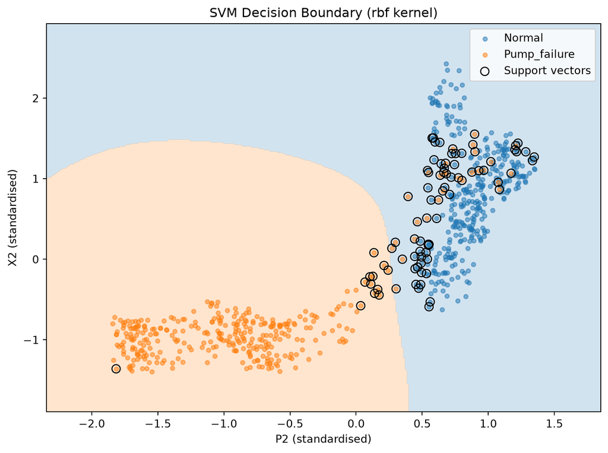

## Conclusion

By the end of this tutorial, you should understand two of the most widely used linear classifiers. **Logistic regression** draws a straight-line boundary by modelling class probabilities, and its `C` hyperparameter controls regularisation. The **support vector machine** draws the maximum-margin boundary, defined by a handful of **support vectors**, and its **kernel** lets it bend that boundary to fit non-linear data. Along the way you also met two evaluation tools that go beyond a single accuracy number (the **confusion matrix** and the **decision boundary plot**) and saw why **feature scaling** matters for distance-based models like the SVM.

A recurring theme is worth restating: when several models perform equally well, prefer the simplest. Both datasets here turned out to be close to linearly separable, so the simplest boundary was already the best one.

## Sources

- [Scikit-learn documentation](https://scikit-learn.org/stable/documentation.html)
- [Logistic Regression](https://scikit-learn.org/stable/modules/linear_model.html#logistic-regression)
- [Support Vector Machines](https://scikit-learn.org/stable/modules/svm.html)
- Khan, U., Pao, W., Pilario, K.E.S., Sallih, N. and Khan, M.R. (2023), “Two-phase flow regime identification using multi-method feature extraction and explainable kernel Fisher discriminant analysis”, *International Journal of Numerical Methods for Heat & Fluid Flow*. [doi:10.1108/HFF-09-2023-0526](https://www.emerald.com/insight/content/doi/10.1108/HFF-09-2023-0526/full/html)